# 02 - Dosage matrix, G/A/H kernels, and cross-validated genomic prediction

# 7 Cross-validation

Two validation schemes, matching the pipeline timeline (calves genotyped in year 2, CFIT phenotypes only from year 4):

- **Forward:** train on generations 8, 9; predict the youngest generation
  10. with their phenotypes masked. This mirrors predicting calves before they are recorded.
- **k-fold:** 3 random folds of the genotyped cows, stratified by breed x country x generation.

Metrics, computed on validation cows only:

- `acc_TBV` = cor(EBV, TBV) - true accuracy (available only because this is a simulation);
- `PA` = cor(EBV, y*) with y* = phenotype minus its herd-generation mean (what real data allow);
- `acc_PA` = PA / sqrt(h<sup>2</sup>) using the file-00 h<sup>2</sup> for the breed mix;
- `acc_within_breed` = cor(EBV, TBV) within each breed, averaged with weights n per breed. This is the accuracy that matters for ranking candidates, because selection is within breed. The pooled `acc_TBV` also rewards or penalises breed-level offsets in the EBVs;
- `slope` = regression of TBV on EBV (1 = unbiased; < 1 = over-dispersed).
- `h2_REML_fit` = h<sup>2</sup> implied by the variance components that REML estimated in that training set (BayesA/B: not applicable). A value near 0 means REML reached the boundary and the EBVs are shrunk to almost nothing, which shows up as a near-zero accuracy and slope.

```r
gd[, fold := NA_integer_]
gd[, fold := sample(rep(seq_len(params$n_folds), length.out = .N)),
   by = .(breed, country, generation)]
schemes <- c(list(forward = gd[generation == max(gens), id]),
             lapply(seq_len(params$n_folds), function(k) gd[fold == k, id]))
names(schemes)[-1] <- paste0("fold", seq_len(params$n_folds))
for (tr in traits) dat[, paste0("ys_", tr) := get(tr) - mean(get(tr)), by = hg]
```

```r
score <- function(ebv, val, tr) {
  v <- dat[id %in% val]
  e <- ebv[as.character(v$id)]
  tbv <- v[[paste0("TBV_", tr)]]; ys <- v[[paste0("ys_", tr)]]
  # within-breed accuracy (selection in file 04 is within breed), weighted by n per breed
  wb <- data.table(b = v$breed, e = e, t = tbv)[, .(r = cor(e, t), n = .N), by = b]
  data.table(acc_TBV = cor(e, tbv), acc_within_breed = sum(wb$r * wb$n) / sum(wb$n),
             PA = cor(e, ys),
             acc_PA = cor(e, ys) / sqrt(h2_mix[[tr]]),
             slope = unname(coef(lm(tbv ~ e))[2]))
}

res <- list(); ebv_fwd <- list()
for (tr in params$focus_traits) for (sc in names(schemes)) {
  val <- schemes[[sc]]
  dtr <- copy(dat)[!(id %in% val)]                  # masked = removed from training data
  gtr <- dtr[genotyped == TRUE]
  out <- list(); h2f <- list(); secs <- list()      # h2f: h2 implied by each REML fit; secs: fit time
  h2_of <- function(f) unname(f$varA / (f$varA + f$varE))
  # ABLUP (pedigree, REML)
  f <- fit_sommer(dtr, Ainv, tr);    out$ABLUP <- f$ebv; h2f$ABLUP <- h2_of(f)
  # GBLUP (REML) and the same prediction via back-solved SNP effects
  f <- fit_sommer(gtr, Gi_reg, tr);  out$GBLUP <- f$ebv; h2f$GBLUP <- h2f$GBLUP_snp <- h2_of(f)
  u_snp <- snp_from_gblup(f$ebv[gid], Gi_reg)
  out$GBLUP_snp <- setNames(as.vector(Z %*% u_snp), gid)
  # ssGBLUP
  tm <- system.time(f <- fit_sommer(dtr, Hinv, tr))[["elapsed"]]
  out$ssGBLUP <- f$ebv; h2f$ssGBLUP <- h2_of(f); secs$ssGBLUP <- tm
  # ssGBLUP with breed metafounders (G05 and A^Gamma; no G rescaling)
  tm <- system.time(f <- fit_sommer(dtr, Hinv_MF, tr))[["elapsed"]]
  out$ssGBLUP_MF <- f$ebv; h2f$ssGBLUP_MF <- h2_of(f); secs$ssGBLUP_MF <- tm
  # weighted ssGBLUP (Wang et al. 2012): 2 iterations; each re-fits ssGBLUP with the new
  # SNP weights. Weights use EBVs of genotyped TRAINING cows only (no validation leakage).
  train_g <- intersect(gid, as.character(gtr$id))
  d_snp <- rep(1, ncol(Z)); a_tr <- f$ebv[train_g]
  for (it in 1:2) {
    Gd_tr <- tcrossprod(sweep(Z[train_g, ], 2, sqrt(d_snp), `*`)) / k2pq
    u0 <- d_snp * as.vector(crossprod(Z[train_g, ],
                  solve(Gd_tr + 0.01 * diag(length(train_g)), a_tr))) / k2pq
    d_snp <- u0^2 * 2 * p * (1 - p); d_snp <- d_snp / mean(d_snp)
    Gw <- tcrossprod(sweep(Z, 2, sqrt(d_snp), `*`)) / k2pq; dimnames(Gw) <- dimnames(G)
    fw <- fit_sommer(dtr, make_Hinv(Gw), tr); a_tr <- fw$ebv[train_g]
  }
  out$wssGBLUP <- fw$ebv; h2f$wssGBLUP <- h2_of(fw)
  # rrBLUP (SNP effects)
  f <- fit_rrblup(gtr, tr)
  out$rrBLUP <- setNames(as.vector(W %*% f$u), gid); h2f$rrBLUP <- h2_of(f)
  # BayesA / BayesB (SNP effects)
  for (m in c("BayesA", "BayesB")) {
    f <- fit_bglr(gtr, tr, m)
    out[[m]] <- setNames(as.vector(W %*% f$u), gid)
  }
  if (sc == "forward") {                            # keep forward EBVs for inspection
    v <- dat[id %in% val, c("id", "breed", paste0("TBV_", tr)), with = FALSE]
    setnames(v, 3, "TBV")
    for (m in names(out)) v[, (m) := out[[m]][as.character(id)]]
    ebv_fwd[[tr]] <- cbind(trait = tr, v)
  }
  for (m in names(out)) res[[paste(tr, sc, m)]] <-
    cbind(data.table(trait = tr, scheme = sc, model = m), score(out[[m]], val, tr),
          h2_REML_fit = if (is.null(h2f[[m]])) NA_real_ else h2f[[m]],
          fit_sec = if (is.null(secs[[m]])) NA_real_ else secs[[m]])
  progress(tr, " ", sc, " done ", format(Sys.time() - t0))
}
```

[output not shown]

```r
res <- rbindlist(res)
```

**Sanity check:** `GBLUP` and `GBLUP_snp` must give identical accuracies, because predicting from back-solved SNP effects is algebraically equivalent to GBLUP.

```r
chk <- dcast(res[model %in% c("GBLUP", "GBLUP_snp")], trait + scheme ~ model, value.var = "acc_TBV")
chk[, diff := abs(GBLUP - GBLUP_snp)]
kable(chk, digits = 4)
```

| trait | scheme | GBLUP | GBLUP_snp | diff |
| --- | --- | --- | --- | --- |
| CH4 | fold1 | 0.1758 | 0.1758 | 0 |
| CH4 | fold2 | 0.0669 | 0.0669 | 0 |
| CH4 | fold3 | 0.1383 | 0.1383 | 0 |
| CH4 | forward | 0.0466 | 0.0466 | 0 |

# 8 Results

```r
summ <- res[model != "GBLUP_snp",
            .(acc_TBV = mean(acc_TBV), acc_TBV_sd = sd(acc_TBV),
              acc_within_breed = mean(acc_within_breed),
              PA = mean(PA), acc_PA = mean(acc_PA), slope = mean(slope),
              h2_fit_min = min(h2_REML_fit), h2_fit_max = max(h2_REML_fit)),
            by = .(trait, model, scheme_type = ifelse(scheme == "forward", "forward", "k-fold"))]
kable(summ[order(trait, scheme_type, -acc_TBV)], digits = 3,
      caption = "Mean accuracy by trait, model and validation scheme (sd across folds)")
```

Mean accuracy by trait, model and validation scheme (sd across folds)

| trait | model | scheme_type | acc_TBV | acc_TBV_sd | acc_within_breed | PA | acc_PA | slope | h2_fit_min | h2_fit_max |
| --- | --- | --- | --- | --- | --- | --- | --- | --- | --- | --- |
| CH4 | ssGBLUP | forward | 0.395 | NA | 0.214 | 0.039 | 0.093 | 1.386 | 0.153 | 0.153 |
| CH4 | wssGBLUP | forward | 0.271 | NA | 0.105 | 0.034 | 0.082 | 0.191 | 0.698 | 0.698 |
| CH4 | ABLUP | forward | 0.270 | NA | 0.190 | 0.074 | 0.177 | 1.605 | 0.123 | 0.123 |
| CH4 | ssGBLUP_MF | forward | 0.226 | NA | 0.213 | 0.046 | 0.111 | 0.960 | 0.208 | 0.208 |
| CH4 | BayesB | forward | 0.064 | NA | 0.163 | -0.019 | -0.045 | 0.204 | NA | NA |
| CH4 | GBLUP | forward | 0.047 | NA | 0.190 | 0.009 | 0.021 | 0.298 | 0.110 | 0.110 |
| CH4 | rrBLUP | forward | 0.047 | NA | 0.190 | 0.009 | 0.021 | 0.298 | 0.108 | 0.108 |
| CH4 | BayesA | forward | -0.043 | NA | 0.193 | 0.013 | 0.031 | -0.154 | NA | NA |
| CH4 | ssGBLUP | k-fold | 0.400 | 0.022 | 0.264 | 0.091 | 0.218 | 1.357 | 0.132 | 0.151 |
| CH4 | wssGBLUP | k-fold | 0.303 | 0.035 | 0.160 | 0.058 | 0.139 | 0.217 | 0.681 | 0.790 |
| CH4 | ssGBLUP_MF | k-fold | 0.287 | 0.032 | 0.264 | 0.099 | 0.237 | 1.134 | 0.181 | 0.206 |
| CH4 | ABLUP | k-fold | 0.272 | 0.014 | 0.242 | 0.100 | 0.238 | 1.268 | 0.118 | 0.139 |
| CH4 | BayesA | k-fold | 0.160 | 0.051 | 0.183 | 0.041 | 0.099 | 0.496 | NA | NA |
| CH4 | rrBLUP | k-fold | 0.127 | 0.055 | 0.184 | 0.043 | 0.102 | 1.304 | 0.039 | 0.114 |
| CH4 | GBLUP | k-fold | 0.127 | 0.055 | 0.184 | 0.043 | 0.102 | 1.305 | 0.040 | 0.116 |
| CH4 | BayesB | k-fold | 0.126 | 0.073 | 0.177 | 0.031 | 0.074 | 0.478 | NA | NA |

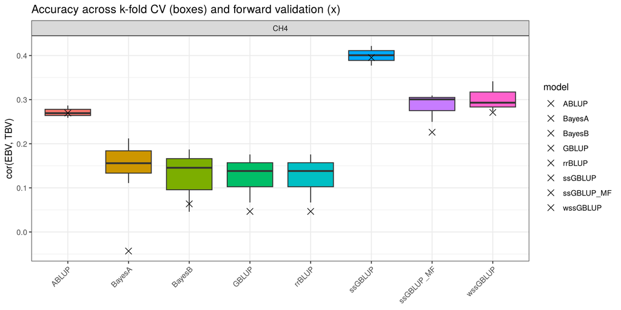

```r
ggplot(res[model != "GBLUP_snp" & scheme != "forward"],
       aes(model, acc_TBV, fill = model)) +
  geom_boxplot(show.legend = FALSE) +
  geom_point(data = res[model != "GBLUP_snp" & scheme == "forward"],
             shape = 4, size = 3, colour = "black") +
  facet_wrap(~trait) +
  labs(y = "cor(EBV, TBV)", x = NULL,
       title = "Accuracy across k-fold CV (boxes) and forward validation (x)") +
  theme_bw() + theme(axis.text.x = element_text(angle = 45, hjust = 1))
```

## 8.1 Which single-step model is more reliable?

Both single-step models use the same data, pedigree and REML. They differ only in how the genomic and pedigree relationships are made compatible: pooled a + bG rescaling (`ssGBLUP`) versus breed metafounders (`ssGBLUP_MF`). **Decision rule (fixed before seeing the result):**

1. Primary criterion: mean **within-breed accuracy** over all focus traits and validation sets, because selection in file 04 is within breed.
2. If the two differ by less than one standard error of the paired difference, the accuracies are treated as equal and the model whose **dispersion slope** is closer to 1 wins (less bias in EBV scale, which matters when EBVs of different breeds or ages are compared).

The chosen model is written to `ssgblup_choice_<focus traits>.csv` and is the single-step model used in file 04.

```r
pw <- dcast(res[model %in% c("ssGBLUP", "ssGBLUP_MF")], trait + scheme ~ model,
            value.var = c("acc_within_breed", "slope", "fit_sec"))
pw[, d_acc := acc_within_breed_ssGBLUP_MF - acc_within_breed_ssGBLUP]
se_d <- sd(pw$d_acc) / sqrt(nrow(pw))
ss_sum <- data.table(model = c("ssGBLUP", "ssGBLUP_MF"),
  acc_within_breed = c(mean(pw$acc_within_breed_ssGBLUP), mean(pw$acc_within_breed_ssGBLUP_MF)),
  mean_abs_slope_dev = c(mean(abs(pw$slope_ssGBLUP - 1)), mean(abs(pw$slope_ssGBLUP_MF - 1))),
  mean_fit_sec = c(mean(pw$fit_sec_ssGBLUP), mean(pw$fit_sec_ssGBLUP_MF)))
kable(ss_sum, digits = 3, caption = "Single-step variants, averaged over traits and validation sets")
```

Single-step variants, averaged over traits and validation sets

| model | acc_within_breed | mean_abs_slope_dev | mean_fit_sec |
| --- | --- | --- | --- |
| ssGBLUP | 0.251 | 0.365 | 28.899 |
| ssGBLUP_MF | 0.251 | 0.111 | 27.229 |

```r
md <- mean(pw$d_acc)
winner <- if (abs(md) >= se_d) { if (md > 0) "ssGBLUP_MF" else "ssGBLUP" } else
  ss_sum[which.min(mean_abs_slope_dev), model]
reason <- if (abs(md) >= se_d) "within-breed accuracy differs by at least 1 SE" else
  "accuracies equal within 1 SE; slope closer to 1"
fwrite(data.table(winner = winner, reason = reason, mean_diff_acc_MF_minus_pooled = md, se_diff = se_d,
                  focus_traits = paste(params$focus_traits, collapse = ",")),
       file.path(params$sim_dir, paste0("ssgblup_choice_", paste(params$focus_traits, collapse = "_"), ".csv")))
```

**Result:** mean within-breed accuracy difference (MF minus pooled) = 0 (SE 0); chosen model: **ssGBLUP_MF** (accuracies equal within 1 SE; slope closer to 1).

## 8.2 Theoretical expectation (sanity check, not a result)

Expected accuracy from Daetwyler et al. (2008, *PLoS ONE* 3:e3395), r = sqrt(N h<sup>2</sup> / (N h<sup>2</sup> + M<sub>e</sub>)), with M<sub>e</sub> = 2 N<sub>e</sub> L / log(4 N<sub>e</sub> L) (Goddard 2009, *Genetica*). N<sub>e</sub> = 90 (CATTLE history), L = genome length in Morgans of the simulated chromosomes (29). This formula assumes one homogeneous population, so it is only a rough reference here.

```r
L  <- sum(sapply(SP$genMap, function(x) max(x)))
Ne <- 90
Me <- 2 * Ne * L / log(4 * Ne * L)
N_train <- nrow(gd) * (params$n_folds - 1) / params$n_folds
theo <- data.table(trait = params$focus_traits,
                   h2 = h2_mix[params$focus_traits])
theo[, r_expected := sqrt(N_train * h2 / (N_train * h2 + Me))]
cat("Genome length L =", round(L, 2), "M | Me =", round(Me), "| N_train =", N_train, "\n")
```

```
## Genome length L = 25.05 M | Me = 495 | N_train = 1006
```

```r
kable(theo, digits = 3)
```

| trait | h2 | r_expected |
| --- | --- | --- |
| CH4 | 0.175 | 0.512 |

# 9 Save

```r
tag <- paste(params$focus_traits, collapse = "_")
fwrite(res, file.path(params$sim_dir, paste0("cv_results_", tag, ".csv")))
fwrite(rbindlist(ebv_fwd), file.path(params$sim_dir, paste0("ebv_forward_", tag, ".csv")))
if (nrow(vc)) fwrite(vc, file.path(params$sim_dir, "vc_gblup.csv"))
saveRDS(list(G = G, A22 = A22, gid = gid, p = p, keep_snp = keep),
        file.path(params$sim_dir, "kernels.rds"))
cat("Run time:", format(Sys.time() - t0), "\n")
```

```
## Run time: 12.51675 mins
```